# Homework 7

Tyler Poelking

3/25/2018

QUESTION 2

```r
set.seed(23422432)

library(rjags)
```

```r
library(boot)
library(ggplot2)
library(grid)
library(gridExtra)
library(reshape2)

# read in the data and calculate some
# summaries
schoolData <- read.table( "~/Desktop/All Stuff/School Stuff/STATS/3303/homework7/friends.txt", header=T )
y <- schoolData$y
x <- schoolData$x
school <- schoolData$school
pair <- schoolData$pair

schoolNames <- unique(school)
schoolsNumeric <- as.numeric(schoolNames)
nSchools = length(schoolNames)

nPairs <- length(schoolData)


# create objects for JAGS
dataList <- list( "y" = y,
                  "x" = x,
                  'pair' = pair,
                  'school' = school,
                  "nPairs" = nPairs,
                  "nSchools" = nSchools)

# list of parameters to be monitored
parameters <- c( 'alpha',"beta", "mu.beta",
                 "mu.alpha",
                 "sigma2.beta",
                 "sigma2.alpha")

# set initial values
initsValues <- list('alpha' = rep(1, nSchools),
                    'beta' = rep(1,nSchools),
                    "mu.beta" = 1,
                     "mu.alpha" = 1,
                    "sigma2.beta" = 5,
                    "sigma2.alpha" = 5)

# number of iteration for "tuning"
adaptSteps <- 5000

# number of iterations for "burn-in"
burnInSteps <- 5000

# number of chains to run
nChains <- 2

# total number of iterations to save
numSavedSteps <- 5000

# "thinning" (1 = keep every interation)
thinSteps <- 1

# iterations per chain
ITER <- ceiling( (numSavedSteps * thinSteps) / nChains )

# -------------
# Run JAGS
# -------------

# create, initialize, and adapt the model
jagsModel <- jags.model( "~/Desktop/All Stuff/School Stuff/STATS/3303/homework7/model.txt",
                         data = dataList,
                         inits = initsValues,
                         n.chains = nChains,
                         n.adapt = adaptSteps )
```

The starting values are available in the code above.

The number of iterations is the ceiling of (numSavedSteps x thinSteps) / nChains = 5000 * 1 / 2

Based on the trace plots, the chains appear to be sampling from the same distribution. This gives reason to believe that the algorithm converged.

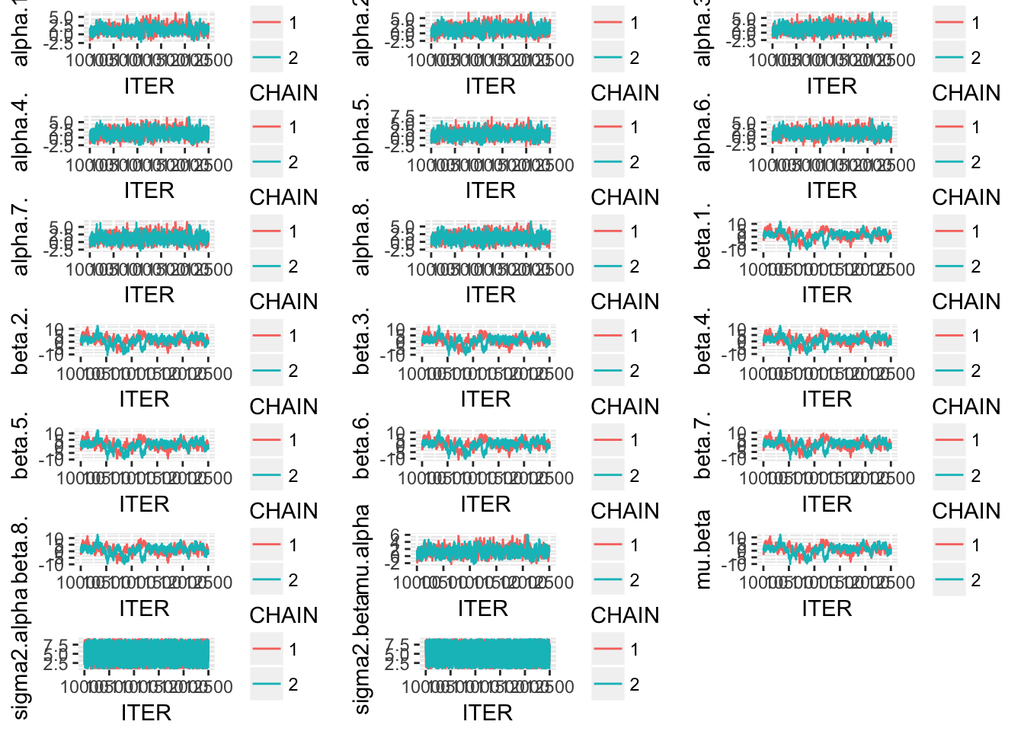

```r
# burn-in the algorithm
update( jagsModel,
        n.iter = burnInSteps )

# run algorithm to get interations for inference
codaSamples <- coda.samples( jagsModel,
                             variable.names = parameters,
                             n.iter = ITER,
                             thin = thinSteps)

# -------------
# Look at posterior samples
# -------------

# make a dataframe with the posterior samples
mcmcChainDF <- data.frame( as.matrix( codaSamples,
                                      iters = T,
                                      chains = T ) )

# create a vector with the variable names
varNames <- names( mcmcChainDF )[3:( dim( mcmcChainDF )[2] )]

# number of variables
nVars <- 20

mcmcChainDF$CHAIN <- as.factor(mcmcChainDF$CHAIN)

# construct trace plots

p <- list()
par(ask = T)
for( k in 1:nVars )
{
  plot_frame <- mcmcChainDF
  plot_frame$dep_var <- mcmcChainDF[ , varNames[k]]
  p[[k]] <- ggplot( plot_frame,
                    aes( x = ITER,
                         y = dep_var))  +
    geom_line( aes( color = CHAIN ) ) +
    labs( y = varNames[k] )
}

do.call( grid.arrange, c( p, list("ncol" = 3)))
```

QUESTION 3

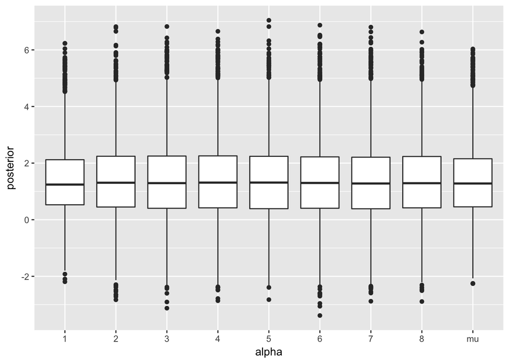

```r
postDFreshape <- melt( mcmcChainDF,
                       id.vars = "ITER",
                       measure.vars = c("alpha.1.",
                                        "alpha.2.",
                                        "alpha.3.",
                                        "alpha.4.",
                                        "alpha.5.",
                                        "alpha.6.",
                                        "alpha.7.",
                                        "alpha.8.",
                                        "mu.alpha"))
ggplot(postDFreshape,
       aes(x = variable, y = value )) +
  geom_boxplot() +
  scale_x_discrete( labels = c( schoolNames, "mu" )) +
  ylab( "posterior" ) +
  xlab( "alpha" )
```

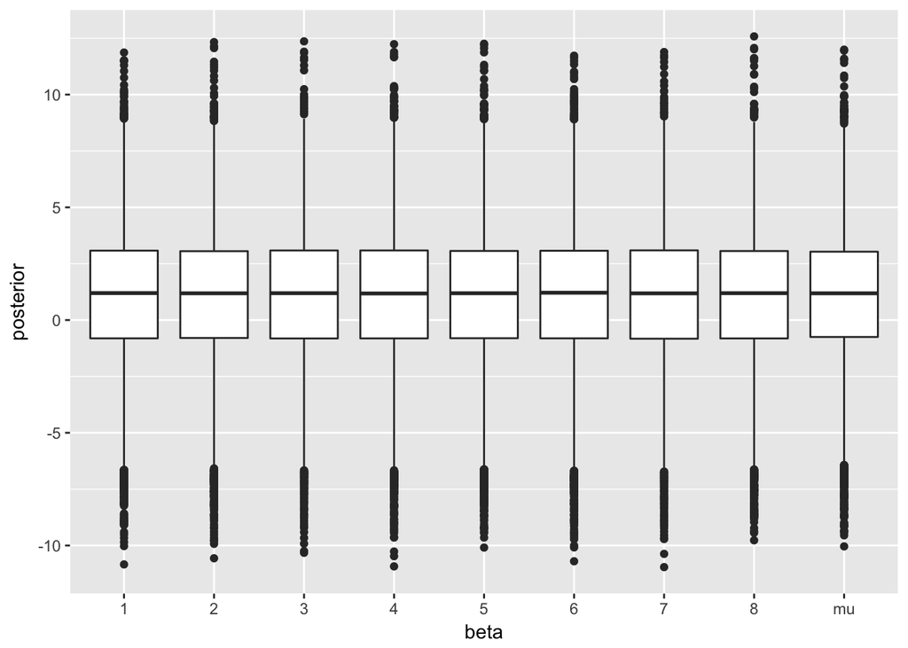

```r
postDFreshape <- melt( mcmcChainDF,
                       id.vars = "ITER",
                       measure.vars = c("beta.1.",
                                        "beta.2.",
                                        "beta.3.",
                                        "beta.4.",
                                        "beta.5.",
                                        "beta.6.",
                                        "beta.7.",
                                        "beta.8.",
                                        "mu.beta"))
ggplot(postDFreshape,
       aes(x = variable, y = value )) +
  geom_boxplot() +
  scale_x_discrete( labels = c( schoolNames, "mu" )) +
  ylab( "posterior" ) +
  xlab( "beta" )
```

The levels of alpha and beta show minimal difference between the 8 schools. All 8 alphas and all 8 betas are very similar to their corresponding averages. This shows that there is not a significant difference between the odds that a pair of students are pairs across school, even when taking mixed vs non-mixed genders into account.

Consider a new school with the same number of juniors as the schools in the dataset. Approximate the predictive probability that an arbitrary pair of two girls at the new school will be close friends

```r
alpha.post <- mcmcChainDF$mu.alpha
prob_alpha.post <- inv.logit(alpha.post)
mean(prob_alpha.post)
```

```
## [1] 0.7374031
```

In addition, approximate the predictive probability that an arbitrary pair of one girl and one boy at the new school will be close friends.

```r
beta.post <- mcmcChainDF$mu.beta
x = alpha.post + beta.post
prob_x.post <- inv.logit(x)
mean(prob_x.post)
```

```
## [1] 0.7487097
```